# Spatial

Evelyn Shi

2025-07-21

Some code and text inspired by Spatial Statistics SISMID Module with Drs. Lance Waller and Howard Chang

# What We Have

Our shapefiles include

- .dbf file: contains attribute table
- .shp file: contains track outlines
- .shx file: connective tissue to link it all together
- .prj file: for map projection
- .cpg file: used to specify the code page to identify character encoding

The two shapefiles are for the cluster polygons (From David, actual lifesaver) and the cases.

# What I’d Like to do

Plot and see at what level cases are clustering – household? block? cluster?

# Data

Load libraries

```r
pacman::p_load(sf, here, tidyverse)
```

Read in shapefiles

```r
## Read in case shapefile - TIRS_SINAVE_22_23
cases <- st_read(dsn = here("data"),
                 layer = "TIRS_SINAVE_22_23")
## Cluster shapefile
clusters <- st_read(dsn = here("data"),
                    layer = "Cluster final 2021 actualizado")
```

# Data Exploration, Learning GIS

## Cluster Map

### Plot Only Clusters

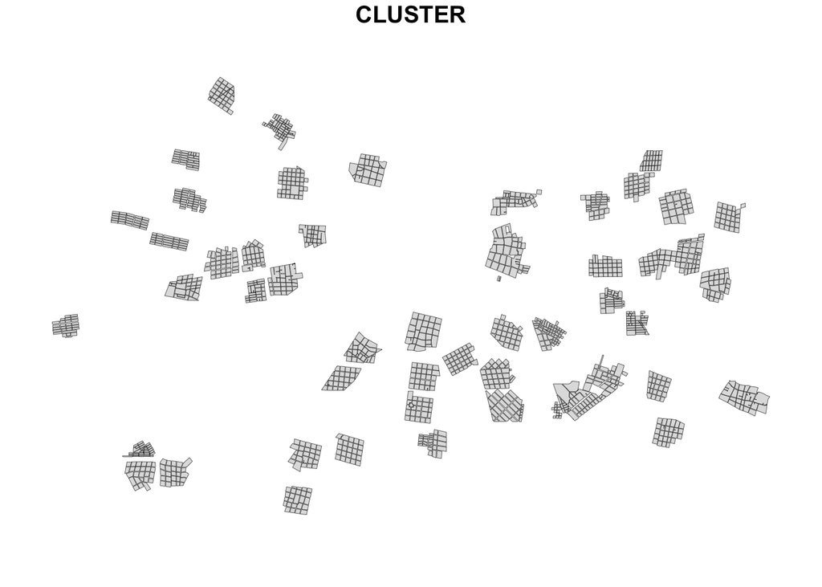

```r
plot(clusters['CLUSTER'],
     col = adjustcolor("grey", alpha=0.5),
     lwd = 0.3)
```

### Plot by TIRS Arm

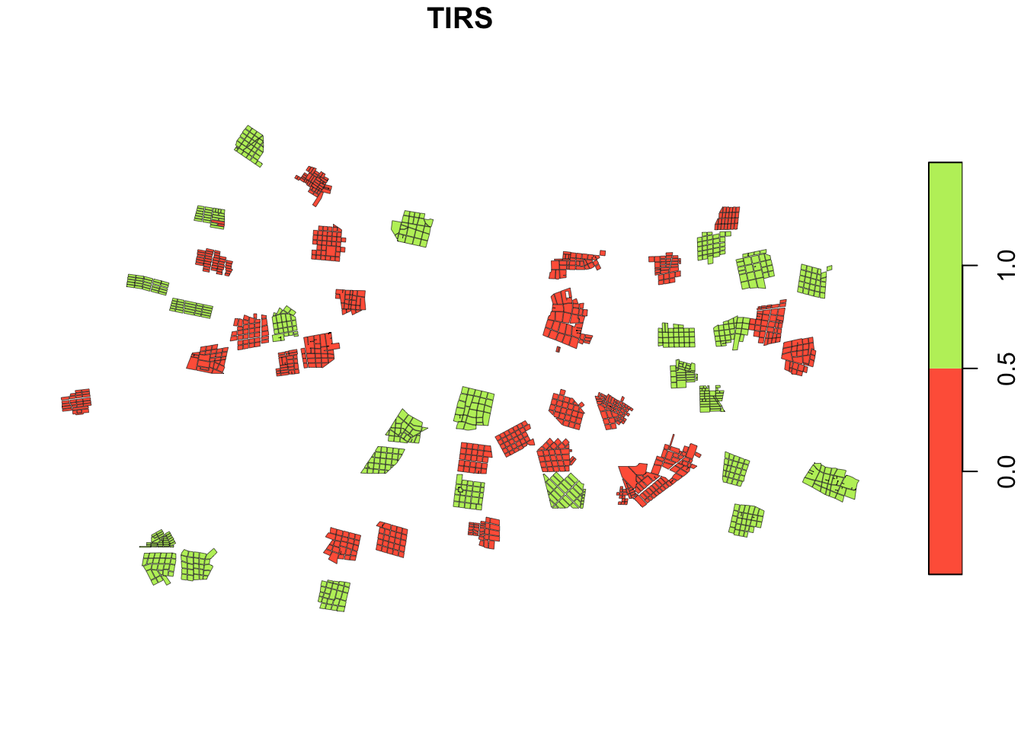

```r
plot(clusters['TIRS'],
     pal = c("tomato", "darkolivegreen2"),
     lwd = 0.3)
```

## Cases Map (by Year)

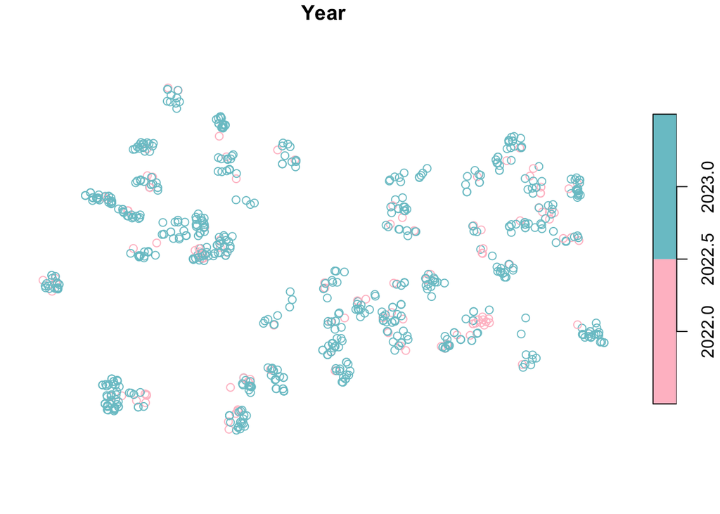

```r
plot(cases["Year"],
     pal = c("pink", "cadetblue3"))
```

# Some Questions

## Households?

Are there households included in this shape file?

### What is Each Polygon?

What are the blocks highlighted right now? Houses? Blocks?

Seems like it might just be block level polygons

### Zoom In?

Right now it seems to just have cluster and block, but maybe I need to zoom in some more?

## Organized Questions

### 1. Is MZCODE an individual house?

If so, are we able to use these shape files to look at houses individually? I’d like to know since it’d make it easier/more obvious to see if there’s any clustering (visually) at the household level

# ggplot

## Full Map

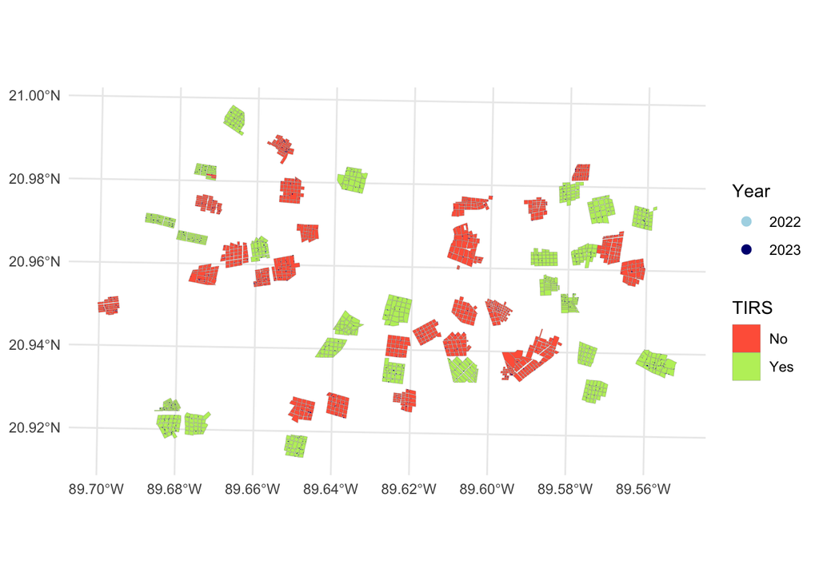

```r
ggplot() +
  geom_sf(data = clusters, linewidth = 0.05, aes(fill = as.factor(TIRS))) +
  geom_sf(data = cases, size = 0.2, stroke = 0,
          aes(color = as.factor(Year))) +
  scale_fill_manual(values = c("tomato", "darkolivegreen2"),
                    name = "TIRS", labels = c("No", "Yes")) +
  guides(color = guide_legend(override.aes = list(size = 3))) +
  scale_color_manual(values = c("lightblue", "navy"),
                    name = "Year", labels = c("2022", "2023")) +
  theme_minimal()
```

```r
ggsave("case_clusters.pdf")
```